# Predicting Excercise Type

### Overview

The following analysis evaluates personal fitness data for the Coursera machine learning course within the data science specialization. The objective is to predict one of five exercise movements using data collected from personal fitness monitors.

Several models are built and tested for accuracy using a hold out dataset. The final result are predicitions for the test set, which is provided without the corresponding exercise movements.

More information on the relative performance of families of machine learning models is available in the following article: http://jmlr.org/papers/volume15/delgado14a/delgado14a.pdf.

### Setup

```r
library(caret)
library(MASS)         ## Linear Discriminant Analysis
library(rpart)        ## Regression Trees
library(randomForest) ## Random Forest
library(ranger)       ## A Fast Random Forest
library(xgboost)      ## Extreme Gradient Boosting
library(e1071)        ## Suppor Vector Machine
```

### Get data

```r
## On the first run, download the csv files

# download.file("https://d396qusza40orc.cloudfront.net/predmachlearn/pml-training.csv", destfile = "training.csv")
# download.file("https://d396qusza40orc.cloudfront.net/predmachlearn/pml-testing.csv", destfile = "testing.csv")

train_raw <- read.csv("training.csv", stringsAsFactors = FALSE)
test_raw  <- read.csv("testing.csv", stringsAsFactors = FALSE)
```

### Prepare data

#### Select factors

Remove character data, timestamps, id, and user name. Also, remove numeric data with any missing values (where there was any missing values, all the values were missing actually).

```r
## Examine character predictors
is_num <- as.numeric(which(sapply(train_raw, class) != "character"))

## Identify numeric predictos with a lot of NAs
na_count <- sapply(train_raw[, is_num], function(x) sum(is.na(x)))

# Select numeric predictors with no NAs
predictors <- is_num[na_count == 0]

## Remove id and raw timestamps
predictors <- predictors[-c(1:3)]

## Response is the last column
response   <- 160
```

#### Create a hold-out set

Since the `testing` data is used for final evaluation and the response is unknown, an out-of-sample validation is needed to evaluate the different models.

```r
is_train <- createDataPartition(train_raw[, response], p = 0.7, list = FALSE)

## Various arrangements for the models
x <- train_raw[is_train, predictors]
y <- factor(train_raw[is_train, response])

## Hold out for out-of-sample error estimates
hold_out_x <- train_raw[-is_train, predictors]
hold_out_y <- factor(train_raw[-is_train, response])

## Final testing dataset
test_x <- test_raw[, predictors]
test_y <- factor(test_raw[, response])
```

#### Preprocess features

```r
proc_obj <- preProcess(x, method = c("scale", "center"))
x_proc   <- predict(proc_obj, x)
```

## Fit models

#### Linear Discriminant Anlaysis

```r
system.time(
  fit_lda <- train(x_proc, y, method = "lda",
                   trControl = trainControl(method = "cv", number = 5))
)
```

```
##    user  system elapsed
##   2.375   0.156   2.569
```

#### Support Vector Machine

The SVM builds multiple binary models (one-against-one) and uses a voting mechanism to determine which class is selected.

```r
system.time(
  fit_svm <- svm(x_proc, y, scale = FALSE)
)
```

```
##    user  system elapsed
##  25.691   0.099  25.803
```

#### Classification Tree

```r
system.time(
  fit_rpart <- train(x_proc, y, method = "rpart")
)
```

```
##    user  system elapsed
##  14.950   0.892  15.855
```

#### Random Forest

Based on the output, there are no major improvements at around 150 trees.

The model is tuned by selecting the number of features to use (mtry) in each individual tree. On multiple runs, the tuning suggests either 14 or 28 features are the preferred setting. For simplicity, mtry is set to 14 even though some runs suggest 28 is slightly better.

```r
## First tune randomeforest
system.time(
  tuneRF(x_proc, y)
)
```

```
## mtry = 7  OOB error = 0.43%
## Searching left ...
## mtry = 4     OOB error = 0.62%
## -0.440678 0.05
## Searching right ...
## mtry = 14    OOB error = 0.21%
## 0.5084746 0.05
## mtry = 28    OOB error = 0.25%
## -0.2068966 0.05
```

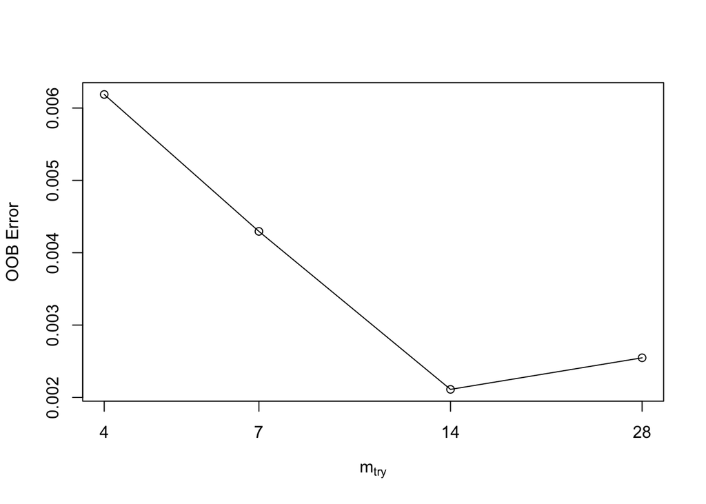

```
##    user  system elapsed
##  15.984   0.095  16.179
```

```r
## Based on tuning, use mtry = 14; output provided for every 10 trees
system.time(
  fit_rf <- randomForest(x_proc, y, do.trace = 10, mtry = 14, ntree = 150)
)
```

```
## ntree      OOB      1      2      3      4      5
##    10:   2.58%  1.06%  3.87%  3.45%  3.46%  1.93%
##    20:   0.75%  0.20%  1.28%  0.83%  1.38%  0.40%
##    30:   0.42%  0.03%  0.71%  0.42%  0.84%  0.36%
##    40:   0.41%  0.03%  0.60%  0.46%  0.80%  0.40%
##    50:   0.31%  0.00%  0.49%  0.42%  0.67%  0.16%
##    60:   0.28%  0.03%  0.49%  0.33%  0.58%  0.16%
##    70:   0.26%  0.03%  0.41%  0.29%  0.53%  0.20%
##    80:   0.24%  0.00%  0.45%  0.29%  0.49%  0.12%
##    90:   0.21%  0.03%  0.38%  0.25%  0.40%  0.12%
##   100:   0.22%  0.00%  0.38%  0.29%  0.40%  0.16%
##   110:   0.24%  0.00%  0.49%  0.21%  0.49%  0.16%
##   120:   0.23%  0.00%  0.41%  0.17%  0.58%  0.16%
##   130:   0.20%  0.00%  0.38%  0.17%  0.49%  0.12%
##   140:   0.20%  0.00%  0.38%  0.13%  0.49%  0.12%
##   150:   0.20%  0.00%  0.41%  0.21%  0.44%  0.08%
```

```
##    user  system elapsed
##  12.123   0.110  12.282
```

#### Faster Random Forest (ranger)

```r
system.time(
  fit_rgr <- ranger(y ~ ., data = cbind(x_proc, y))
)
```

```
##    user  system elapsed
##  22.033   0.407   6.194
```

#### Extreme Gradient Boosting

```r
## --------------------------------------------------
## Convert y to numeric values, starting at 0
## A = 0
## B = 1
## ...
num_y <- sapply(y, function(x) which(LETTERS == x)) - 1

## Create DMatrix object to speed up processing
xy_xgb <- xgb.DMatrix(as.matrix(x_proc), label = num_y)

## Set parameters & run model
## Objective is for multiple classes
param <- list("objective" = "multi:softprob",
              "eval_metric" = "mlogloss",
              "num_class" = 5)

## Run the model with 10 rounds
system.time(
  fit_xgb <- xgboost(xy_xgb, param = param, nrounds = 10, verbose = 1)
)
```

```
##    user  system elapsed
##   2.515   0.006   2.524
```

#### Optional: save models

```r
#save(fit_lda, fit_rpart, fit_rf, fit_rgr, fit_xgb, fit_svm, file = "models.RData")
```

### Evaluate

#### Setup

Preprocess features using same object from training. Also, create a standard eval function for use in most cases.

```r
new_x <- predict(proc_obj, hold_out_x)
new_y <- hold_out_y

## Function to evaluate model
eval_model <- function(model) {
  res <- predict(model, new_x)
  metrics <- confusionMatrix(res, new_y)$overall
  metrics <- round(metrics, 4)
  m_name <- deparse(substitute(model))
  cbind(data.frame(Model = m_name), t(metrics))
}

options(scipen = 999, digits = 4)
```

#### Prediction Metrics

Based on accuracy, the tuned random forest and the `ranger` random forest perform the best, though the speed of the `ranger` implementation is significantly better.

Morevier, if processing time is a priority, the xgboost algorithm is very fast with about the same accuracy.

```r
## Straightforward metrics
m1 <- eval_model(fit_lda)
m2 <- eval_model(fit_svm)
m3 <- eval_model(fit_rpart)
m4 <- eval_model(fit_rf)

## Fast Random Forest
res <- predict(fit_rgr, new_x)
metrics <- confusionMatrix(res$predictions, new_y)$overall
metrics <- round(metrics, 4)
m5 <- cbind(data.frame(Model = "fit_rgr"), t(metrics))

## Extreme Gradient Boosting
new_xgb <- xgb.DMatrix(as.matrix(new_x))
res <- predict(fit_xgb, new_xgb, reshape = TRUE)

i <- apply(res, 1, which.max)
pred <- factor(LETTERS[i])

metrics <- confusionMatrix(pred, hold_out_y)$overall
metrics <- round(metrics, 4)
m6 <- cbind(data.frame(Model = "fit_xgb"), t(metrics))

rbind(m1, m2, m3, m4, m5, m6)
```

```
##       Model Accuracy  Kappa AccuracyLower AccuracyUpper AccuracyNull
## 1   fit_lda   0.7162 0.6408        0.7045        0.7277       0.2845
## 2   fit_svm   0.9556 0.9438        0.9501        0.9608       0.2845
## 3 fit_rpart   0.4931 0.3378        0.4803        0.5060       0.2845
## 4    fit_rf   0.9978 0.9972        0.9962        0.9988       0.2845
## 5   fit_rgr   0.9978 0.9972        0.9962        0.9988       0.2845
## 6   fit_xgb   0.9776 0.9716        0.9735        0.9812       0.2845
##   AccuracyPValue McnemarPValue
## 1              0             0
## 2              0           NaN
## 3              0           NaN
## 4              0           NaN
## 5              0           NaN
## 6              0           NaN
```

### Predict response on test set

Use the fast random forest model from the `ranger` package.

```r
new_x <- predict(proc_obj, test_x)
new_y <- test_y

pred <- predict(fit_rgr, new_x)
pred$predictions
```

```
##  [1] B A B A A E D B A A B C B A E E A B B B
## Levels: A B C D E
```